# Stressors in the LGB Population

Zoe Habel

People who identify as sexual gender minorities such as lesbian, gay, or bisexual are at unique risks for several health outcomes. In order to further explore some of the potential vulnerabilities for certain health outcomes, I analyzed a national cohort study of LGB people[^1]. The survey was given in 3 waves once a year for 3 years, so there is longitudinal data on participants as well.

To look at some of the unique circumstances, I decided to look at the measures of Everyday Discrimination, Internalized Homophobia, Psychological Distress and Social Wellbeing as potential contributing factors to negative health outcomes. I was interested in seeing if certain identities are more likely to experience certain healthcare outcomes. Additionally, I also wanted to see how well represented different groups were across the study as a whole and at each wave.

```r
sexuality_barplotW1 <- ggplot(
  generations_combined,
  aes(x = W1SEXMINID, fill =W1SEXMINID)
                             ) +
  geom_bar() +
  scale_fill_canva(
    palette = "Pop art",
    labels = c("Lesbian/Gay", "Bisexual","Other")
                  ) +
  labs(
    x = NULL,
    y = "# of Participants",
    fill = "Sexual Minority\nIdentity",
    title = "Wave 1"
      ) +
  theme_classic()


sexuality_barplotW2 <- ggplot(
  W2generations_combined,
  aes(x = W2SEXMINID, fill =W2SEXMINID)
                             ) +
  geom_bar() +
  scale_fill_canva(
    palette = "Pop art",
    labels = c("Lesbian/Gay", "Bisexual","Other")
                  ) +
  labs(
    x = NULL,
    y = "# of Participants",
    fill = "Sexual Minority\nIdentity",
    title = "Wave 2"
      ) +
  theme_classic()

sexuality_barplotW3 <- ggplot(
  W3generations_combined,
  aes(x = W3SEXMINID, fill =W3SEXMINID)
                             ) +
  geom_bar() +
  scale_fill_canva(
    palette = "Pop art",
    labels = c("Lesbian/Gay", "Bisexual","Other")
                  ) +
  labs(
    x = NULL,
    y = "# of Participants",
    fill = "Sexual Minority\nIdentity",
    title = "Wave 3"
      ) +
  theme_classic()
```

```r
allwaves_sexuality_barplot <- ggplot(
  sexualities,
  aes(x = SEXMINID, fill =ALLSEXMINID)
                                    ) +
  geom_bar(position="fill") +
  scale_y_continuous(
    name = "% of Participants",
    labels = scales::label_percent())+
  scale_fill_grey(
    labels = c("Wave 1", "Wave 2","Wave 3")
                       ) +
  labs(
    x = "Sexual Minority Identity",
    fill = "Survey Wave",
    title = "All Waves"
      ) +
  theme_classic()
```

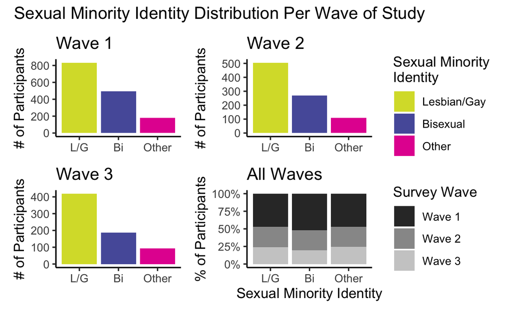

```r
sexuality_barplotW1 + sexuality_barplotW2 + sexuality_barplotW3 + allwaves_sexuality_barplot +
  plot_layout(guides = 'collect') +
  plot_annotation(title = "Sexual Minority Identity Distribution Per Wave of Study")
```

I chose stacked bar plots to display the distribution of different identities accross all 3 waves. As seen in the bar plots, **Lesbian and Gay adults are overrepresented accross all 3 waves.** Depending on how much outcomes vary by identity, this could greatly impact the signifcance of the findings and is a methodological weakness.

```r
internalized_plotW1 <- ggplot(generations_combined,
                              aes(x = W1SEXMINID, y = W1INTERNALIZED_I, fill = W1SEXMINID)) +
  geom_boxplot() +
  scale_fill_canva(
    palette = "Pop art",
    labels = c("Lesbian/Gay", "Bisexual","Other")
                  ) +
  labs(y = "Internalized\nHomophobia", x = NULL, fill = "Sexual Minority\nIdentity") +
  theme_classic()
everyday_plotW1 <- ggplot(generations_combined,
                          aes(x = W1SEXMINID, y = W1EVERYDAY_I, fill = W1SEXMINID)) +
  geom_boxplot() +
  scale_fill_canva(     palette = "Pop art",     labels = c("Lesbian/Gay", "Bisexual","Other")                   ) +
  labs(y = "Everyday\nDiscrimination", x = NULL, fill = "Sexual Minority\nIdentity") +
  theme_classic()

kessler6_plotW1 <-
  ggplot(
  generations_combined,
  aes(x = W1SEXMINID, y = W1KESSLER6_I, fill = W1SEXMINID)
        ) +
  geom_boxplot() +
  scale_fill_canva(
    palette = "Pop art",
    labels = c("Lesbian/Gay", "Bisexual","Other")
                  ) +
  labs(
    y = "Psychological\nDistress",
    x = NULL, fill = "Sexual Minority\nIdentity"
      ) +
  theme_classic()

social_wb_plotW1 <-
  ggplot(
  generations_combined,
  aes(x = W1SEXMINID, y = W1SOCIALWB_I, fill = W1SEXMINID)
        ) +
  geom_boxplot() +
  scale_fill_canva(
    palette = "Pop art",
    labels = c("Lesbian/Gay", "Bisexual","Other")
                  ) +
  labs(
    y =  "Social\nWellbeing",
    x = NULL,
    fill = "Sexual Minority\nIdentity"
      )+
  theme_classic()
```

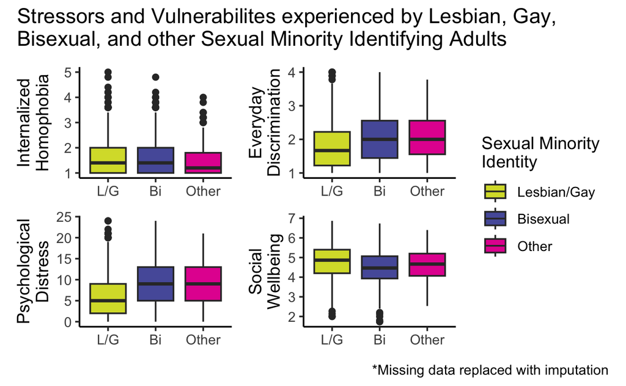

```r
internalized_plotW1 + everyday_plotW1 + kessler6_plotW1 + social_wb_plotW1 +
  plot_layout(guides = 'collect') +
  plot_annotation(title = "Stressors and Vulnerabilites experienced by Lesbian, Gay,\nBisexual, and other Sexual Minority Identifying Adults", caption = "*Missing data replaced with imputation")
```

To in look at the distribution of different sexual minority identities for certain risk factors, I chose to use side-by-side box plots.

These boxplots all use data from Wave 1, because it has the most participants. **For each risk factor, the boxplots overlap, suggesting that the difference between groups is minimal**. People identifying as **bisexual** or an other sexual minority identity showed **higher median scores for psychological distress and everyday discrimination**, and those identifying as **lesbian, gay or bisexual** showed slightly **larger median internalized homophobia compared scores** to other identities. For **social wellbeing**, people identifying as **bisexual** had the **lowest median scores**.

A limitation of this report is that the colors are not color-blind friendly. If these results were to be published, I would utilize color-blind friendly colors or shapes to more clearly differentiate the data. Additionally, without more rigorous statistical analysis, it is not possible to conclude whether or not these results are statistically significant, but these plots do bring to light the differences between the experiences of people with different sexual minority identities and the need to develop targeted studies and interventions with these differences in mind.

Though LGB people share similar struggles, their unique identities can make them more susceptible to certain circumstances.

Previous research has shown bisexual to face greater issues with community belonging, because they are isolated and separated from both homosexual and heterosexual groups, as well as being more susceptible to invalidation of their identity. These figures support these previous findings, suggesting that bisexual people and other sexual minorities may be **more susceptible** to certain risk factors.

[^1]: Meyer, I. H. (2023). Generations: A Study of the Life and Health of LGB People in a Changing Society, United States, 2016-2019 [Dataset]. Inter-university Consortium for Political and Social Research [distributor]. https://doi.org/10.3886/ICPSR37166.v2